First Year Paper: Bayes Factor Test for NAM Beta Coefficients

**Afra Kilic**  
**Supervisor: dr. ir. Joris Mulder**  
**01-09-2022**

Loading required packages

First, the required packages have to be loaded. You can access to the overview of the packages on Github. The simulation data will be generated by using the package sna. Then, by using these generated data, NAM will be fitted by using the function lnam.

```r
library(sna)
```

The Simulation Study

$$\begin{align*}
y = \beta_{0} + X\beta_1 + \rho Wy + \epsilon, \qquad \epsilon &\sim {\sf Norm}(0, \sigma^2I_g)
\end{align*}$$

Two-Sided Hypothesis Testing: Savage Dickey Ratio Approach

The Following Function bf_averages generates network autocorrelation model data using the specified parameters as input variables. Then it tests hypotheses against each other: $H_{0}: \beta = 0$ and $H_{1}: \beta \neq 0$ for the simulated data and calculates the $B_{01}$ using the Savage-Dickey ratio method with a unit information prior.

- In the columns: Average Bayes Factor ($B_{01}$) and average of $log(B_{01})$ for the $\beta_{1}$.
- In the rows: Beta sequence of 20 between -2 and 2.

Input variables:

- sigma2 : $\sigma^{2}$
- n : $g$, network size
- rho : $\rho$, network effect
- d : $d$, network density

```r
bf_averages <- function(sigma2 = 1, n = 50, rho = 0.2, d = 0.2){

   beta_seq <- seq(-2, 2, length.out = 20) #Beta Sequence
   BF_averages_1 <- c() #for the average of 1000 B01
   BF_log_averages_1 <- c()  #for the average of 1000 log(B01)
   BF_post_averages <- c() #for the average of 1000 posterior probabilities

   for (i in 1: 20){

     beta <- cbind(rep(1, 1000),rep(beta_seq[i], 1000)) #Covariate Matrix
     BayesFactor_B1 <- c() #B01 Arrays for for Beta1 estimates
     BF_post <- c()

     #Network Autocorrelation Data Generation

     for (j in 1:1000){
       Wadj <- sna::rgraph(n, tprob = d, mode = "graph")
       W <- sna::make.stochastic(Wadj, mode = "row")
       X <- matrix(c(rep(1, n), rnorm(n*1)), nrow=n, ncol=2)

       y <- c((solve(diag(n) - rho*W))%*%(X%*%beta[j,] + rnorm(n, sd = sqrt(sigma2))))
       y <- y - mean(y)

       model1 <- sna::lnam(y, X, W)#network autocorrelation model fit

       #Bayes Factor Calculation for Beta1
       post1 <- dnorm(0, mean = model1$beta[2,1], model1$beta.se[2]) #posterior distribution
       prior1 <- dnorm(0, mean = model1$beta[2,1], model1$beta.se[2]*sqrt(n)) #unit information prior distribution
       fact1 <- post1/prior1
       BayesFactor_B1 <- c(BayesFactor_B1, fact1)
       BF_post <- c(BF_post, fact1/(fact1 +1))
     }
     BF_averages_1 <- c(BF_averages_1, mean(BayesFactor_B1))
     BF_log_averages_1 <- c(BF_log_averages_1, mean(log(BayesFactor_B1)))
     BF_post_averages <- c(BF_post_averages, mean(BF_post))
   }
   results <- cbind(BF_averages_1, BF_log_averages_1, BF_post_averages)
   return(results)
 }
```

Bayes Factor Test for Beta Coefficients of NAM for Different Network Sizes (Savage-Dickey Ratio)

- To display of how $B_{01}$ behaves across different network sizes, $\{g \in 20, 50, 100\}$, and $\beta{1}$ values for the Savage-Dickey ratio method:

```r
BF_beta_20 <- bf_averages(n = 20) #network size = 20 with the default values of sigma2 = 1, rho = 0.2, d = 0.2.
BF_beta_50 <- bf_averages(n = 50) #network size = 50 with the default values of sigma2 = 1, rho = 0.2, d = 0.2.
BF_beta_100 <- bf_averages(n = 100) #network size = 100 with the default values of sigma2 = 1, rho = 0.2, d = 0.2.
```

```r
beta_seq <- seq(-2, 2, length.out = 20) # beta sequence for Beta1 values
```

Visualizing the results

- Following plots show how $B_{01}$, posterior probabilities and $log(B_{01})$ behave across different network sizes and $\beta_{1}$ values.
- where posterior probabilities refer to $P(H_{0}|y) = \frac{B_{01}}{B_{01}+1}$

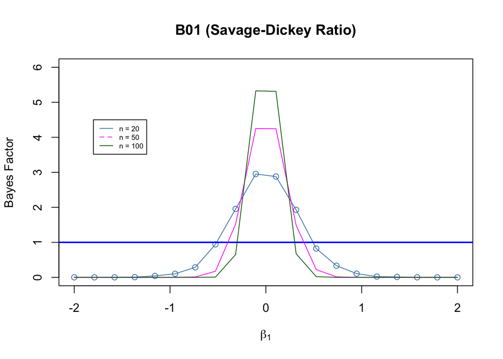

```r
#B01 (Savage-Dickey Ratio)
# n = 20
plot(beta_seq, BF_beta_20[,1], main = "B01 (Savage-Dickey Ratio)", xlab = expression(beta[1]), ylab = "Bayes Factor",  ylim = c(0,6), col = "steel blue", type = 'o')
abline(h = 1, col = "blue", lwd = 2)
# n = 50
lines(beta_seq, BF_beta_50[,1], col = "magenta")
# n = 100
lines(beta_seq, BF_beta_100[,1], col = "darkgreen")
legend(-1.8, 4.5, legend = c("n = 20", "n = 50", "n = 100"),
       col = c("steel blue", "magenta", "dark green"), lty = 1:2, cex = 0.6)
```

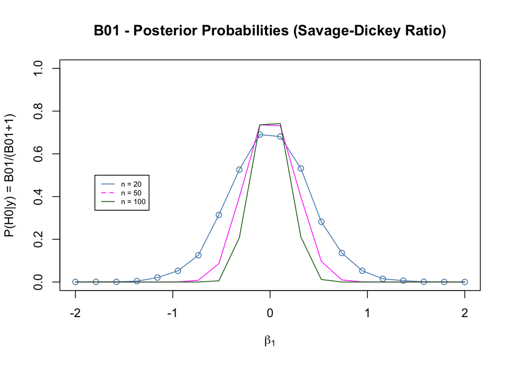

```r
#Posterior Probabilities (Savage-Dickey Ratio)
# n = 20
plot(beta_seq, BF_beta_20[,3], main = "B01 - Posterior Probabilities (Savage-Dickey Ratio)", xlab = expression(beta[1]), ylab = "P(H0|y) = B01/(B01+1)", col = "steelblue", type = 'o', ylim = c(0,1))
# n = 50
lines(beta_seq, BF_beta_50[,3], col = "magenta")
# n = 50
lines(beta_seq, BF_beta_100[,3], col = "darkgreen")

legend(-1.8, 0.5, legend = c("n = 20", "n = 50", "n = 100"),
       col = c("steel blue", "magenta", "dark green"), lty = 1:2, cex = 0.6)
```

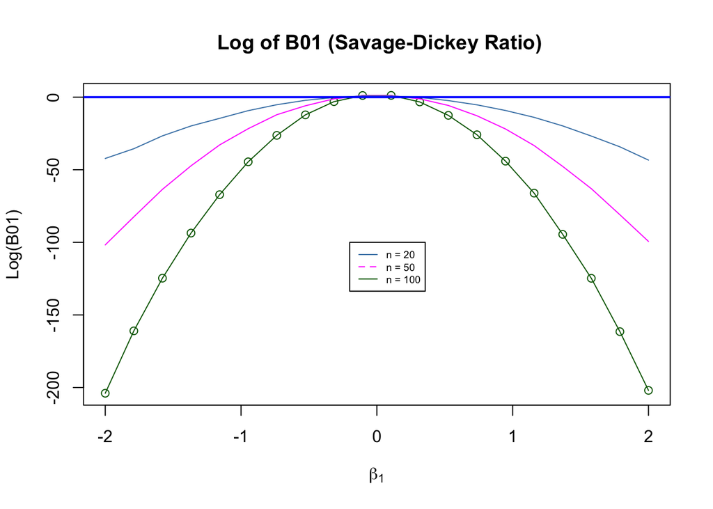

```r
# Log of B01 (Savage-Dickey Ratio)
# n = 20
plot(beta_seq, BF_beta_100[,2], main = " Log of B01 (Savage-Dickey Ratio)", xlab = expression(beta[1]), ylab = "Log(B01)", col = "dark green", type = 'o')
# n = 50
lines(beta_seq, BF_beta_50[,2], col = "magenta")
# n = 100
lines(beta_seq, BF_beta_20[,2], col = "steel blue")
legend(-0.2, -100, legend = c("n = 20", "n = 50", "n = 100"),
       col = c("steel blue", "magenta", "dark green"), lty = 1:2, cex = 0.6)
abline(h = 0, col = "blue", lwd = 2)
```

Two-Sided Hypothesis Testing: BIC Approximation

The Following Function bic_averages generates network autocorrelation model data using the specified parameters as input variables. Then it tests hypotheses against each other: $H_{0}: \beta = 0$ and $H_{1}: \beta \neq 0$ for the simulated data and calculates the $B_{01}$ using the BIC approximation.

It returns 20X5 matrix:

- In the columns: BIC scores for the models where beta is excluded ($H_{0}$) and included ($H_{1}$) respectively. Bayes Factor ($B_{01}$) calculated based on the BIC approximation, posterior probabilities and average of $log(B_{01})$.
- In the rows: Beta sequence of 20 between -2 and 2.

Input variables:

- sigma2 : $\sigma^{2}$
- n : $g$, network size
- rho : $\rho$, network effect
- d : $d$, network density

```r
bic_averages <- function(sigma2 = 1, n = 50, rho = 0.2, d = 0.2){

  beta_seq <- seq(-2, 2, length.out = 20) #Beta Sequence
  BIC_averages0 <- c() #the averages of 1000 BIC scores of model H0 for each beta
  BIC_averages1 <- c() # the averages of 1000 BIC scores of model H1 for each beta
  BF_01_averages <- c() # the averages of 1000 B01 for each beta
  BF_post_averages <- c() # the averages of 1000 posterior probability of B01 for each beta
  log_averages <- c() #the averages of 1000 log(B01) for each beta

  for (i in 1: 20){ #for each beta value

    beta <- cbind(rep(1, 1000),rep(beta_seq[i], 1000)) #Covariate Matrix
    BIC_H0 <- c() #BIC scores of model H0 for the specified beta1
    BIC_H1 <- c() #BIC scores of model H0 for the specified beta1
    BF_01 <- c()  #B01
    BF_post <- c() #posterior probabilities

    for (j in 1:1000){

      #Network Autocorrelation Data Generation
      Wadj <- sna::rgraph(n, tprob = d, mode = "graph")
      W <- sna::make.stochastic(Wadj, mode = "row")
      X <- matrix(c(rep(1, n), rnorm(n*1)), nrow=n, ncol=2)
      y <- c((solve(diag(n) - rho*W))%*%(X%*%beta[j,] + rnorm(n, sd = sqrt(sigma2))))
      y <- y - mean(y)

      model_H1 <- sna::lnam(y, X, W) #network autocorrelation model fit (beta 1 included)

      #BIC Calculation
      res1 <- model_H1$residuals
      w <- rep(1, n)
      ll1<- model_H1$lnlik.model
      bic1 <- -2 * ll1  + 4*log(n)
      BIC_H1 <- c(BIC_H1, bic1)


      model_H0 <- sna::lnam(y, X[,1], W) #network autocorrelation model fit (beta 1 IS NOT included)


      #BIC Calculation
      res0 <- model_H0$residuals
      w <- rep(1, n)
      ll0<- model_H0$lnlik.model
      bic0 <- -2 * ll0  + 3*log(n)
      BIC_H0 <- c(BIC_H0, bic0)

      #Bayes Factor Calculation from BIC
      bf <- exp(-(bic0 - bic1)/2)
      BF_01 <- c(BF_01, bf)

      BF_post <- c(BF_post, bf/(bf +1)) #posterior probabilities

    }

    BIC_averages0 <- c(BIC_averages0, mean(BIC_H0))
    BIC_averages1 <- c(BIC_averages1, mean(BIC_H1))
    BF_01_averages <- c(BF_01_averages, mean(BF_01))
    BF_post_averages <- c(BF_post_averages, mean(BF_post))
    log_averages <- c(log_averages, mean(log(BF_01)))

  }
  results <- cbind(BIC_averages0, BIC_averages1, BF_01_averages, BF_post_averages, log_averages)
  return(results)
}
```

Bayes Factor Test for Beta Coefficients of NAM for Different Network Sizes (BIC Approximation)

- To display of how $B_{01}$ behaves across different network sizes, $g \in \{20, 50, 100\}$, and $\beta{1}$ values for BIC approximation:

```r
bic_20 <- bic_averages(n = 20) #network size = 20 with the default values of sigma2 = 1, rho = 0.2, d = 0.2.
bic_50 <- bic_averages(n = 50) #network size = 50 with the default values of sigma2 = 1, rho = 0.2, d = 0.2.
bic_100 <- bic_averages(n = 100) #network size = 100 with the default values of sigma2 = 1, rho = 0.2, d = 0.2.
```

Visualizing the Results

- Following plots show how $B_{01}$, posterior probabilities and $log(B_{01})$ behave across different network sizes and $\beta_{1}$ values.
- where $B_{01} \sim exp[(BIC(H_{1}) - BIC(H_{0})) / 2]$ and posterior probabilities: $P(H_{0}|y) = \frac{B_{01}}{B_{01}+1}$

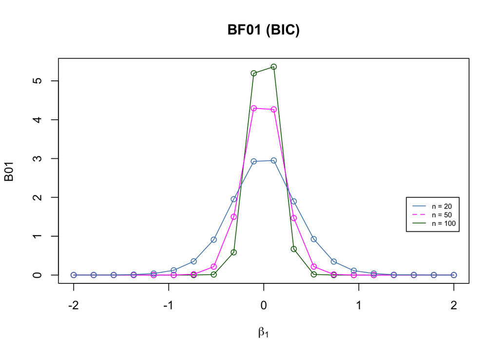

```r
#B01 - BIC Approximation
plot(beta_seq, bic_100[,3], type = "o", col = "darkgreen", main = "BF01 (BIC)",
     xlab = expression(beta[1]), ylab = "B01")
lines(beta_seq, bic_50[,3], col = "magenta", type = "o")
lines(beta_seq, bic_20[,3], col = "steel blue", type = "o")
legend(1.5, 2, legend = c("n = 20", "n = 50", "n = 100"),
       col = c("steel blue", "magenta", "dark green"), lty = 1:2, cex = 0.6)
```

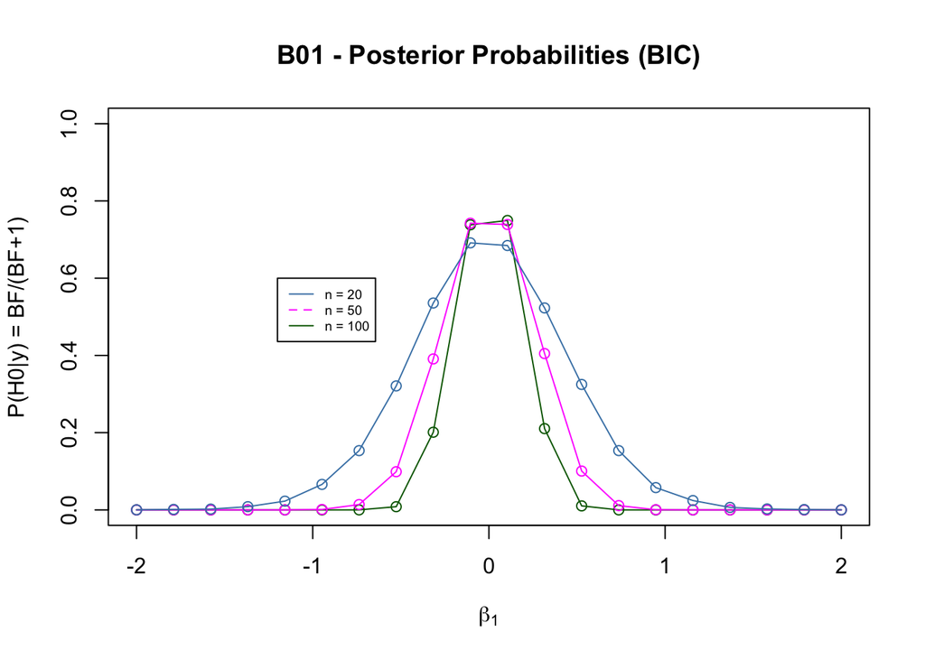

```r
# Posterior Probabilities - BIC Approximation
plot(beta_seq, bic_100[,4], type = "o", col = "darkgreen", main = "B01 - Posterior Probabilities (BIC)",
     xlab = expression(beta[1]), ylab = "P(H0|y) = BF/(BF+1)", ylim = c(0, 1))
lines(beta_seq, bic_50[,4], col = "magenta", type = "o")
lines(beta_seq, bic_20[,4], col = "steel blue", type = "o")
legend(-1.2, 0.6, legend = c("n = 20", "n = 50", "n = 100"),
       col = c("steel blue", "magenta", "dark green"), lty = 1:2, cex = 0.6)
```

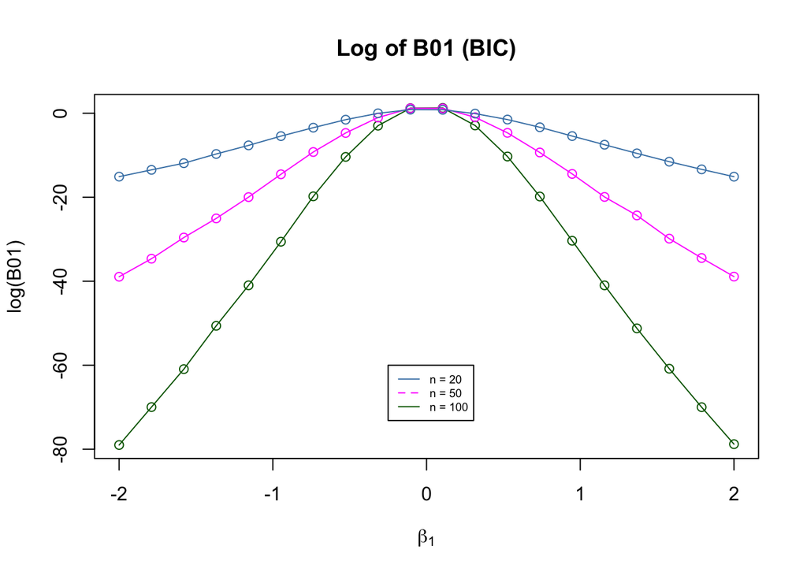

```r
#log(B01) - BIC Approximation
plot(beta_seq, bic_100[,5], type = "o", col = "darkgreen", main = "Log of B01 (BIC)",
     xlab = expression(beta[1]), ylab = "log(B01)")
lines(beta_seq, bic_50[,5], col = "magenta", type = "o")
lines(beta_seq, bic_20[,5], col = "steel blue", type = "o")
legend(-0.25, -60, legend = c("n = 20", "n = 50", "n = 100"),
       col = c("steel blue", "magenta", "dark green"), lty = 1:2, cex = 0.6)
```

Discussion

Trial with Different Network Effect Sizes and Densities

- To display of how $B_{01}$ behaves across different $\rho$ and density values when $g = 50$ for both Savage-Dickey and BIC methods.

Network Effect ($\rho$)

- Three levels of network effect: $\rho \in \{ 0, .2, .5 \}$ with the default values of $\sigma^{2} = 1$ , $d = .2$ and $g = 50$.

```r
rho <- c(0, .2, .5)

rho_mat <- matrix(c(rep(NA, 20)), ncol = 1, nrow = 20)
for (i in 1:3){
rho_mat <- cbind(rho_mat, bf_averages(rho = rho[i]))
}

rho_mat <- rho_mat[,c(-1)]

rho_mat_bic <- matrix(c(rep(NA, 20)), ncol = 1, nrow = 20)
for (i in 1:3){
rho_mat_bic <- cbind(rho_mat_bic, bic_averages(rho = rho[i])[,c(3,5)])
}

rho_mat_bic <- rho_mat_bic[,c(-1)]
```

Densities ($d$)

- Six level of Network Densities: $d \in \{.1, .2, .3, .4, .5, .6 \}$ with the default values of $\sigma^{2} = 1$ , $\rho = .2$ and $g = 50$.

```r
d <- c(0.1, 0.2, 0.3, 0.4, 0.5, 0.6)
density_mat <- matrix(c(rep(NA, 20)), ncol = 1, nrow=20)
for (i in 1:6){
 density_mat <- cbind(density_mat, bf_averages(d = d[i]))
}
density_mat <- density_mat[, c(-1)]

density_mat_bic <- matrix(c(rep(NA, 20)), ncol = 1, nrow = 20)
for (i in 1:6){
density_mat_bic <- cbind(density_mat_bic, bic_averages(d = d[i])[,c(3,5)])
}

density_mat_bic <- density_mat_bic[,c(-1)]
```

Visualizing the Results

Savage-Dickey

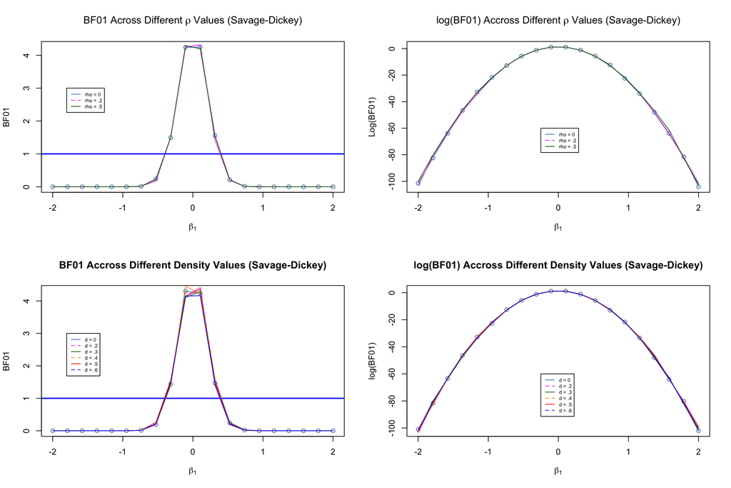

```r
par(mfrow = c(2,2))

# BF01 Across Different rho Values (Savage-Dickey)
plot(beta_seq, rho_mat[,1], main = expression(paste("BF01 Across Different ", rho, " Values (Savage-Dickey)")), xlab = expression(beta[1]), ylab = "BF01",
     type = "o",  col = "steel blue")
abline(h = 1, col = "blue", lwd = 2)
lines(beta_seq, rho_mat[,3], col = "magenta")
lines(beta_seq, rho_mat[,5], col = "darkgreen")
legend(-1.8, 3, legend = c("rho = 0", "rho = .2", "rho = .5"),
       col = c("steel blue", "magenta", "dark green"), lty = 1:2, cex = 0.6)


#log(BF01) Accross Different rho Values (Savage-Dickey)
plot(beta_seq, rho_mat[,2], main =expression(paste("log(BF01) Accross Different ", rho, " Values (Savage-Dickey)")), xlab = expression(beta[1]), ylab = "Log(BF01)",
     type = "o", col = "steel blue")
lines(beta_seq, rho_mat[,4], col = "magenta")
lines(beta_seq, rho_mat[,6], col = "darkgreen")
legend(-.25, -60, legend = c("rho = 0", "rho = .2", "rho = .5"),
       col = c("steel blue", "magenta", "dark green"), lty = 1:2, cex = 0.6)


#BF01 Accross Different Density Values (Savage-Dickey)
plot(beta_seq, density_mat[,1], main = "BF01 Accross Different Density Values (Savage-Dickey)", xlab = expression(beta[1]), ylab = "BF01",
     type = "o", col = "steel blue")
abline(h = 1, col = "blue", lwd = 2)
lines(beta_seq, density_mat[,3], col = "magenta")
lines(beta_seq, density_mat[,5], col = "darkgreen")
lines(beta_seq, density_mat[,7], col = "darkorange")
lines(beta_seq, density_mat[,9], col = "red")
lines(beta_seq, density_mat[,11], col = "blue")
legend(-1.8, 3, legend = c("d = 0", "d = .2", "d = .3", "d = .4", "d = .5", "d = .6"),
       col = c("steel blue", "magenta", "dark green", "darkorange", "red", "blue"), lty = 1:2, cex = 0.6)


#log(BF01) Accross Different Density Values (Savage-Dickey)
plot(beta_seq, density_mat[,2], main = "log(BF01) Accross Different Density Values (Savage-Dickey)", xlab = expression(beta[1]), ylab = "log(BF01)",
     type = "o", col = "steel blue")
lines(beta_seq, density_mat[,4], col = "magenta")
lines(beta_seq, density_mat[,6], col = "darkgreen")
lines(beta_seq, density_mat[,8], col = "darkorange")
lines(beta_seq, density_mat[,10], col = "red")
lines(beta_seq, density_mat[,12], col = "blue")
legend(-.25, -60, legend = c("d = 0", "d = .2", "d = .3", "d = .4", "d = .5", "d = .6"),
       col = c("steel blue", "magenta", "dark green", "darkorange", "red", "blue"), lty = 1:2, cex = 0.6)
```

BIC

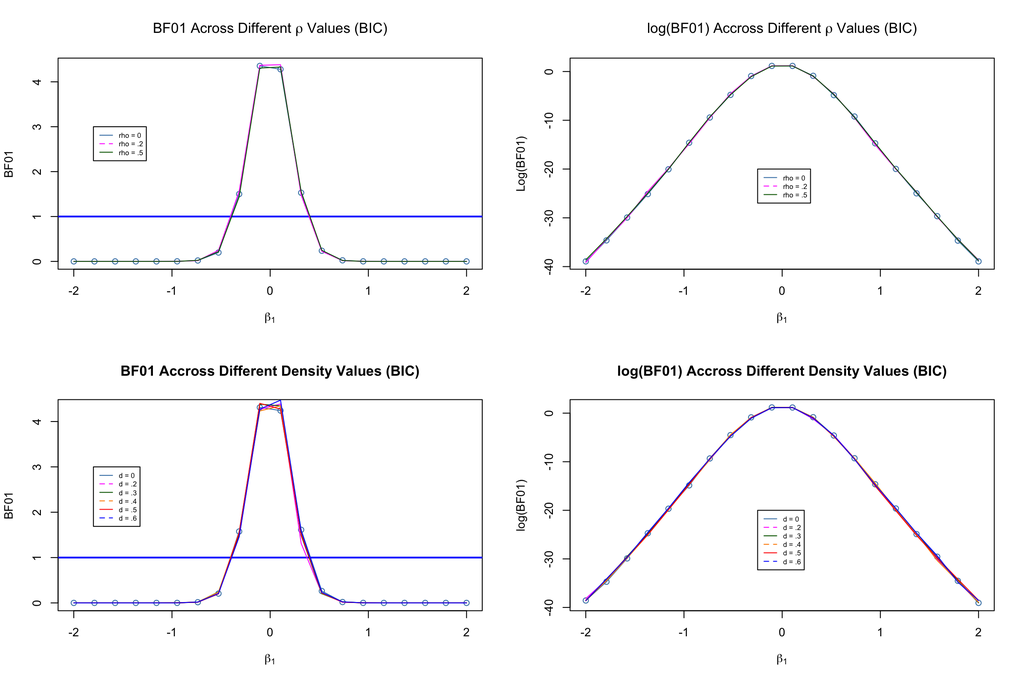

```r
par(mfrow = c(2,2))

# BF01 Across Different rho Values (BIC)
plot(beta_seq, rho_mat_bic[,1], main = expression(paste("BF01 Across Different ", rho, " Values (BIC)")), xlab = expression(beta[1]), ylab = "BF01",
     type = "o",  col = "steel blue")
abline(h = 1, col = "blue", lwd = 2)
lines(beta_seq, rho_mat_bic[,3], col = "magenta")
lines(beta_seq, rho_mat_bic[,5], col = "darkgreen")
legend(-1.8, 3, legend = c("rho = 0", "rho = .2", "rho = .5"),
       col = c("steel blue", "magenta", "dark green"), lty = 1:2, cex = 0.6)



# log(BF01) Across Different rho Values (BIC)
plot(beta_seq, rho_mat_bic[,2], main =expression(paste("log(BF01) Accross Different ", rho, " Values (BIC)")), xlab = expression(beta[1]), ylab = "Log(BF01)",
     type = "o", col = "steel blue")
lines(beta_seq, rho_mat_bic[,4], col = "magenta")
lines(beta_seq, rho_mat_bic[,6], col = "darkgreen")
legend(-.25, -20, legend = c("rho = 0", "rho = .2", "rho = .5"),
       col = c("steel blue", "magenta", "dark green"), lty = 1:2, cex = 0.6)


#BF01 Accross Different Density Values (BIC)
plot(beta_seq, density_mat_bic[,1], main = "BF01 Accross Different Density Values (BIC)", xlab = expression(beta[1]), ylab = "BF01",
     type = "o", col = "steel blue")
abline(h = 1, col = "blue", lwd = 2)
lines(beta_seq, density_mat_bic[,3], col = "magenta")
lines(beta_seq, density_mat_bic[,5], col = "darkgreen")
lines(beta_seq, density_mat_bic[,7], col = "darkorange")
lines(beta_seq, density_mat_bic[,9], col = "red")
lines(beta_seq, density_mat_bic[,11], col = "blue")
legend(-1.8, 3, legend = c("d = 0", "d = .2", "d = .3", "d = .4", "d = .5", "d = .6"),
       col = c("steel blue", "magenta", "dark green", "darkorange", "red", "blue"), lty = 1:2, cex = 0.6)


#log(BF01) Accross Different Density Values (BIC)
plot(beta_seq, density_mat_bic[,2], main = "log(BF01) Accross Different Density Values (BIC)", xlab = expression(beta[1]), ylab = "log(BF01)",
     type = "o", col = "steel blue")
lines(beta_seq, density_mat_bic[,4], col = "magenta")
lines(beta_seq, density_mat_bic[,6], col = "darkgreen")
lines(beta_seq, density_mat_bic[,8], col = "darkorange")
lines(beta_seq, density_mat_bic[,10], col = "red")
lines(beta_seq, density_mat_bic[,12], col = "blue")
legend(-.25, -20, legend = c("d = 0", "d = .2", "d = .3", "d = .4", "d = .5", "d = .6"),
       col = c("steel blue", "magenta", "dark green", "darkorange", "red", "blue"), lty = 1:2, cex = 0.6)
```

- $B_{01}$ behaves similar across different $\rho$ and $d$ values either in Savage-Dickey or in BIC. $log(B_{01})$ graphs clearly show that $B_{01}$ based on Savage-Dickey method is much more sensitive to changes in $\beta_{1}$.

Bayes Factor for Multiple Testing

bf_multiple_testing generates network autocorrelation model data using the specified parameters as input variables. Then it tests the following hypotheses for the simulated data and calculates $B_{01}$ using the Savage-dickey ratio method. The function uses a multivariate normal prior with a mean of zero and variance equal to the expected information matrix for one information, that is ${\sf N}(0, \hat{\sigma^2_{\beta}}/\sqrt{g})ß$.

- $H_{0}: \beta_{1} = 0$
- $H_{0}: \beta_{1} < 0$
- $H_{0}: \beta_{1} > 0$
- $H_{u}: \beta_{1} \in \mathbb{R}$  
  and  
  returns **20X6 matrix**:
- In the **columns** respectively: Average $B_{01}$, $B_{02}$, $B_{12}$ and average of $log(B_{01})$, $log(B_{02})$, $log(B_{12})$.
- In the **rows**: Beta sequence of 20 between -2 and 2.

where,

- $\beta_{01}$ = $\frac{\beta_{u0}}{\beta_{u1}}$
- $\beta_{02}$ = $\frac{\beta_{u0}} {\beta_{u2}}$
- $\beta_{12}$ = $\frac{\beta_{u1}} {\beta_{u2}}$

Input variables:

- sigma2 : $\sigma^{2}$
- n : $g$, network size
- rho : $\rho$, network effect
- d : $d$, network density

```r
bf_multiple_testing <- function(sigma2 = 1, n = 50, rho = 0.2, d = 0.2){
  #Beta Sequence
  beta_seq <- seq(-2, 2, length.out = 20)

  BF01_averages <- rep(NA, 20)
  BF02_averages <- rep(NA, 20)
  BF12_averages <- rep(NA, 20)
  BF01_log_averages <- rep(NA, 20)
  BF02_log_averages <- rep(NA, 20)
  BF12_log_averages <- rep(NA, 20)
  for (i in 1: 20){
    #Beta Array
    beta <- cbind(rep(1, 1000),rep(beta_seq[i], 1000))
    #Bayes Factor Arrays for for Beta Estimators
    B01 <- rep(NA, 1000)
    B02 <- rep(NA, 1000)
    B12 <- rep(NA, 1000)
    #Network Autocorrelation Data Generation

    for (j in 1:1000){
      Wadj <- sna::rgraph(n, tprob = d, mode = "graph")
      W <- sna::make.stochastic(Wadj, mode = "row")
      X <- matrix(c(rep(1, n), rnorm(n*1)), nrow=n, ncol=2)

      y <- c((solve(diag(n) - rho*W))%*%(X%*%beta[j,] + rnorm(n, sd = sqrt(sigma2))))
      y <- y - mean(y)


      #H0: Beta = 0
      #H1: Beta < 0
      #H2: Beta > 0
      #Hu: Beta ∈ R

      #network autocorrelation model fit
      model1 <- sna::lnam(y, X, W)

      #Bu0
      post0 <- dnorm(0, mean = model1$beta[2,1], model1$beta.se[2]) #posterior distribution
      prior0 <- dnorm(0, mean = 0, model1$beta.se[2]*sqrt(n)) #unit information prior distribution
      fact0 <- post0/prior0

      #Bu1
      post1 <- pnorm(0, mean = model1$beta[2,1], model1$beta.se[2], lower.tail = TRUE) #posterior distribution
      prior1 <- pnorm(0, mean = 0, model1$beta.se[2]*sqrt(n), lower.tail = TRUE) #unit information prior distribution
      fact1 <- post1/prior1

      #Bu2
      post2 <- pnorm(0, mean = model1$beta[2,1], model1$beta.se[2], lower.tail = FALSE) #posterior distribution
      prior2 <- pnorm(0, mean = 0, model1$beta.se[2]*sqrt(n), lower.tail = FALSE) #unit information prior distribution
      fact2 <- post2/prior2

      #BAYES FACTOR CALCULATION

      B01[j] <- fact0/fact1
      B02[j] <- fact0/fact2
      B12[j] <- fact1/fact2

    }

    BF01_averages[i] <- mean(B01)
    BF02_averages[i] <- mean(B02)
    BF12_averages[i] <- mean(B12)
    BF01_log_averages[i] <- mean(log(B01))
    BF02_log_averages[i] <- mean(log(B02))
    BF12_log_averages[i] <- mean(log(B12))
  }
  results <- cbind(BF01_averages, BF02_averages, BF12_averages, BF01_log_averages, BF02_log_averages, BF12_log_averages)
  return(results)
}
```

Bayes Factor Test for Beta Coefficients of NAM for Different Network Sizes (Multiple Testing)

- To display of how $B_{01}$ and $B_{02}$ behave across different network sizes, $\{g \in 20, 50, 100\}$, and $\beta{1}$ values for Multiple Testing.

```r
multi_20 <- bf_multiple_testing(n=20) #network size = 20 with the default values of sigma2 = 1, rho = 0.2, d = 0.2.
multi_50 <- bf_multiple_testing(n=50) #network size = 50 with the default values of sigma2 = 1, rho = 0.2, d = 0.2.
multi_100 <- bf_multiple_testing(n=100) #network size = 100 with the default values of sigma2 = 1, rho = 0.2, d = 0.2.
```

Visualizing the Results

- Following plots show how $log(B_{01})$ and $log(B_{02})$ behave across different network sizes, $\{g \in 20, 50, 100\}$, and $\beta_{1}$ values.

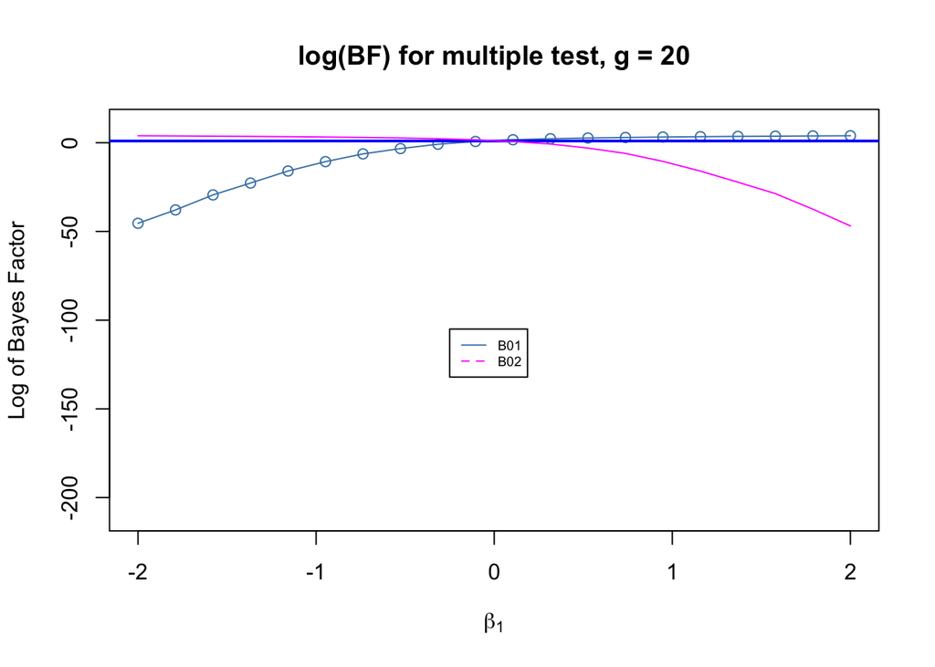

```r
##network size = 20
plot(beta_seq, multi_20[,4], main = "log(BF) for multiple test, g = 20", xlab = expression(beta[1]), ylab = "Log of Bayes Factor",
     type = "o", col = "steel blue", ylim = c(-210, 10))
abline(h = 1, col = "blue", lwd = 2)
lines(beta_seq, multi_20[,5], col = "magenta")
legend(-0.25,-105,  legend = c("B01", "B02"),
       col = c("steel blue", "magenta"), lty = 1:2, cex = 0.6)
```

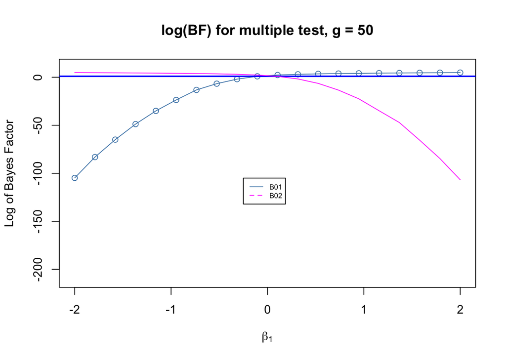

```r
#network size = 50
plot(beta_seq, multi_50[,4], main = "log(BF) for multiple test, g = 50", xlab = expression(beta[1]), ylab = "Log of Bayes Factor",
     type = "o", col = "steel blue", ylim = c(-210, 10))
abline(h = 1, col = "blue", lwd = 2)
lines(beta_seq, multi_50[,5], col = "magenta")
legend(-0.25,-105,  legend = c("B01", "B02"),
       col = c("steel blue", "magenta"), lty = 1:2, cex = 0.6)
```

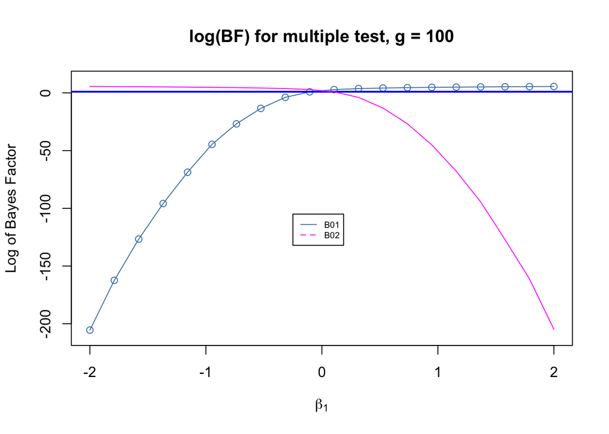

```r
#network size = 100
plot(beta_seq, multi_100[,4], main = "log(BF) for multiple test, g = 100", xlab = expression(beta[1]), ylab = "Log of Bayes Factor",
     type = "o", col = "steel blue", ylim = c(-210, 10))
abline(h = 1, col = "blue", lwd = 2)
lines(beta_seq, multi_100[,5], col = "magenta")
legend(-0.25,-105,  legend = c("B01", "B02"),
       col = c("steel blue", "magenta"), lty = 1:2, cex = 0.6)
```

Discussion

Trial with Different Network Effect Sizes and Densities

- To display of how $log(B_{01})$ and $log(B_{02})$ behave across different $\rho$ and density values when $g = 50$ for multiple testing.

Network Effect ($\rho$)

- Three levels of network effect: $\rho \in \{ 0, .2, .5 \}$ with the default values of $\sigma^{2} = 1$ , $d = .2$ and $g = 50$.

```r
rho <- c(0, .2, .5)

rho_mat_multi <- matrix(c(rep(NA, 20)), ncol = 1, nrow = 20)
for (i in 1:3){
rho_mat_multi <- cbind(rho_mat_multi, bf_multiple_testing(rho = rho[i]))
}

rho_mat_multi <- rho_mat_multi[,c(-1)]
```

Densities ($d$)

- Six level of Network Densities: $d \in \{.1, .2, .3, .4, .5, .6 \}$ with the default values of $\sigma^{2} = 1$ , $\rho = .2$ and $g = 50$.

```r
d <- c(0.1, 0.2, 0.3, 0.4, 0.5, 0.6)
density_mat_multi <- matrix(c(rep(NA, 20)), ncol = 1, nrow=20)
for (i in 1:6){
 density_mat_multi <- cbind(density_mat_multi, bf_multiple_testing(d = d[i]))
}
density_mat_multi <- density_mat_multi[, c(-1)]
```

Visualizing the Results

- Following plots show how $log(B_{01})$ and $log(B_{02})$ behave across different network effects ($\rho$), densities ($d$), and $\beta_{1}$ values.

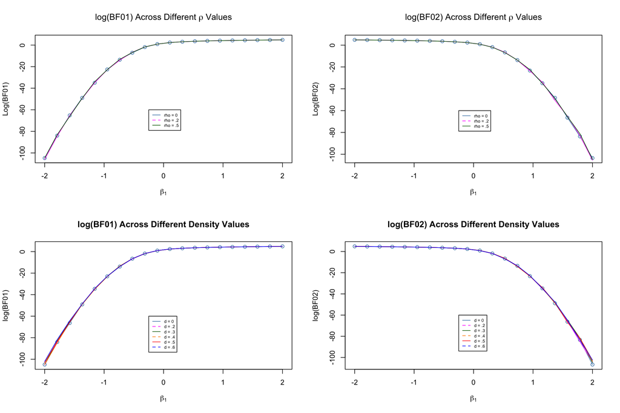

```r
par(mfrow = c(2,2))

#log(BF01) Across Different rho Values
plot(beta_seq, rho_mat_multi[,4], main =expression(paste("log(BF01) Across Different ", rho, " Values")), xlab = expression(beta[1]), ylab = "Log(BF01)",
     type = "o", col = "steel blue")
lines(beta_seq, rho_mat_multi[,10], col = "magenta")
lines(beta_seq, rho_mat_multi[,16], col = "darkgreen")
legend(-.25, -60, legend = c("rho = 0", "rho = .2", "rho = .5"),
       col = c("steel blue", "magenta", "dark green"), lty = 1:2, cex = 0.6)


#log(BF02) Across Different rho Values
plot(beta_seq, rho_mat_multi[,5], main =expression(paste("log(BF02) Across Different ", rho, " Values")), xlab = expression(beta[1]), ylab = "Log(BF02)",
     type = "o", col = "steel blue")
lines(beta_seq, rho_mat_multi[,11], col = "magenta")
lines(beta_seq, rho_mat_multi[,17], col = "darkgreen")
legend(-.25, -60, legend = c("rho = 0", "rho = .2", "rho = .5"),
       col = c("steel blue", "magenta", "dark green"), lty = 1:2, cex = 0.6)


#log(BF01) Across Different Density Values
plot(beta_seq, density_mat_multi[,4], main = "log(BF01) Across Different Density Values", xlab = expression(beta[1]), ylab = "log(BF01)",
     type = "o", col = "steel blue")
lines(beta_seq, density_mat_multi[,10], col = "magenta")
lines(beta_seq, density_mat_multi[,16], col = "darkgreen")
lines(beta_seq, density_mat_multi[,22], col = "darkorange")
lines(beta_seq, density_mat_multi[,28], col = "red")
lines(beta_seq, density_mat_multi[,34], col = "blue")
legend(-.25, -60, legend = c("d = 0", "d = .2", "d = .3", "d = .4", "d = .5", "d = .6"),
       col = c("steel blue", "magenta", "dark green", "darkorange", "red", "blue"), lty = 1:2, cex = 0.6)



#log(BF02) Across Different Density Values
plot(beta_seq, density_mat_multi[,5], main = "log(BF02) Across Different Density Values", xlab = expression(beta[1]), ylab = "log(BF02)",
     type = "o", col = "steel blue")
lines(beta_seq, density_mat_multi[,11], col = "magenta")
lines(beta_seq, density_mat_multi[,17], col = "darkgreen")
lines(beta_seq, density_mat_multi[,23], col = "darkorange")
lines(beta_seq, density_mat_multi[,29], col = "red")
lines(beta_seq, density_mat_multi[,35], col = "blue")
legend(-.25, -60, legend = c("d = 0", "d = .2", "d = .3", "d = .4", "d = .5", "d = .6"),
       col = c("steel blue", "magenta", "dark green", "darkorange", "red", "blue"), lty = 1:2, cex = 0.6)
```

- Bayes factors also in multiple hypothesis test behave similarly across different $\rho$ and $d$ values.

Real Data Examples

In the following, we applied the two-sided and multiple Bayes factor hypothesis testing to two data sets from the literature to analyze the performance of Bayes factor test for $\beta$ coefficients. First, we tested the hypotheses $H_{0}: \beta = 0$ versus $H_{1}: \beta \neq 0$ for each variable with Savage-Dickey ratio method and BIC approximation. Second, we conducted multiple hypothesis testing for the same variables and test the hypotheses $H_{0}: \beta_{1} = 0$ versus $H_{1}: \beta_{1} < 0$ versus $H_{2}: \beta_{1} > 0$.

Boston Housing Data

In this example, we re-analyzed the Boston housing data described by Harrsion and Rubinfeld (1978) and openly accessible in the R package spdep.

```r
#install.packages("spdep")
library(spdep)
data(boston)
```

Data Preparation

Bivand et al. (2014) analyzed the data fitting spatial lag regression model with maximum likelihood estimation. In particular, they estimated the median value of owner-occupied houses (which has been censored $50K) using 13 relevant covariates and spatial structure of the data (Pace and Gilley, 1997). Adjacency is defined in the R object “boston.soi” and we used the row standardized matrix as in the original study (Bivand et al., 2014).

```r
#Adjacency Matrix
W_boston <- nb2mat(boston.soi, glist=NULL, style="W", zero.policy=NULL)
W <- sna::make.stochastic(W_boston, mode = "row")

#X Matrix
X_boston <- cbind("Intercept" = 1,
                  "CRIM" = boston.c$CRIM,
                  "ZN" = boston.c$ZN,
                  "INDUS" = boston.c$INDUS,
                  "CHAS" = boston.c$CHAS,
                  "I(NOXˆ2)" = I(boston.c$NOX^2),
                  "I(RMˆ2)" = I(boston.c$RM^2),
                  "AGE" = boston.c$AGE,
                  "log(DIS)" = log(boston.c$DIS),
                  "log(RAD)" = log(boston.c$RAD),
                  "TAX" = boston.c$TAX,
                  "PTRATIO" = boston.c$PTRATIO,
                  "B" = boston.c$B,
                  "log(LSTAT)" = log(boston.c$LSTAT)
)


#Vector of responses
y_boston <- log(boston.c$CMEDV)
```

NAM Model Fit using lnam

```r
model_boston <- sna::lnam(y_boston, X_boston, W)
summary(model_boston)
```

```
##
## Call:
## sna::lnam(y = y_boston, x = X_boston, W1 = W)
##
## Residuals:
##      Min       1Q   Median       3Q      Max
## -0.70098 -0.08860 -0.00560  0.08245  0.85497
##
## Coefficients:
##              Estimate Std. Error Z value Pr(>|z|)
## Intercept   2.272e+00  1.764e-01  12.884  < 2e-16 ***
## CRIM       -7.105e-03  9.855e-04  -7.209 5.62e-13 ***
## ZN          3.798e-04  3.851e-04   0.986 0.323974
## INDUS       1.257e-03  1.800e-03   0.699 0.484816
## CHAS        7.368e-03  2.574e-02   0.286 0.774717
## I(NOXˆ2)   -2.689e-01  8.873e-02  -3.031 0.002441 **
## I(RMˆ2)     6.724e-03  9.989e-04   6.731 1.68e-11 ***
## AGE        -2.768e-04  4.010e-04  -0.690 0.489968
## log(DIS)   -1.583e-01  2.551e-02  -6.204 5.49e-10 ***
## log(RAD)    7.069e-02  1.460e-02   4.841 1.29e-06 ***
## TAX        -3.657e-04  9.341e-05  -3.915 9.04e-05 ***
## PTRATIO    -1.201e-02  3.950e-03  -3.041 0.002362 **
## B           2.843e-04  7.859e-05   3.618 0.000297 ***
## log(LSTAT) -2.322e-01  2.077e-02 -11.177  < 2e-16 ***
## rho1.1      4.854e-01  2.830e-02  17.151  < 2e-16 ***
## ---
## Signif. codes:  0 '***' 0.001 '**' 0.01 '*' 0.05 '.' 0.1 ' ' 1
##
##       Estimate Std. Error
## Sigma   0.1388          0
##
## Goodness-of-Fit:
##  Residual standard error: 0.1771 on 491 degrees of freedom (w/o Sigma)
##  Multiple R-Squared: 0.8244, Adjusted R-Squared: 0.819
##  Model log likelihood: 264 on 490 degrees of freedom (w/Sigma)
##  AIC: -496 BIC: -428.4
##
##  Null model: meanstd
##  Null log likelihood: -264.2 on 504 degrees of freedom
##  AIC: 532.4 BIC: 540.9
##  AIC difference (model versus null): 1028
##  Heuristic Log Bayes Factor (model versus null):  969.2
```

Crime Data

We considered a cross-sectional data set for 49 neighbourhoods in Columbus, OH, in 1980 which is a part of Columbus data and openly accessible in the R package spdep (Bivand and Piras, 2015).

```r
library(spdep)
data(columbus)
```

Data Preparation

Anselin (1988) analyzed the data to explain the neighbourhoods’ crime rates, operationalized as the total residential burglaries and vehicle thefts per thousand households in the neighborhood, by using network autocorrelation model. Crime rates were modeled as a function of intercept term, household income (INC), housing value (HOVAL) and spatial structure of the data. Adjacency is defined in the R object “col.gal.nb”.

```r
#Adjacency Matrix
W_crime <- nb2mat(col.gal.nb) #transforming the neighborhood list into a matrix

#X matrix
X_crime <- cbind("Intercept" = 1, "INC" = columbus$INC, "HOVAL" = columbus$HOVAL) #covariates: income, housing value

#Vector of responses
y_crime <- columbus$CRIME #DV: residential burglaries and vehicle thefts per thousand households in the neighborhood
```

NAM Model Fit using lnam

```r
model_crime <- sna::lnam(y_crime, X_crime, W_crime)
summary(model_crime)
```

```
##
## Call:
## sna::lnam(y = y_crime, x = X_crime, W1 = W_crime)
##
## Residuals:
##      Min       1Q   Median       3Q      Max
## -35.0963  -6.2818  -0.7896   7.9411  26.7187
##
## Coefficients:
##           Estimate Std. Error Z value Pr(>|z|)
## Intercept 46.85166    8.02524   5.838 5.28e-09 ***
## INC       -1.07354    0.33483  -3.206  0.00134 **
## HOVAL     -0.27000    0.08988  -3.004  0.00266 **
## rho1.1     0.40389    0.12774   3.162  0.00157 **
## ---
## Signif. codes:  0 '***' 0.001 '**' 0.01 '*' 0.05 '.' 0.1 ' ' 1
##
##       Estimate Std. Error
## Sigma    9.958      1.033
##
## Goodness-of-Fit:
##  Residual standard error: 11.24 on 45 degrees of freedom (w/o Sigma)
##  Multiple R-Squared: 0.5608, Adjusted R-Squared: 0.5218
##  Model log likelihood: -183.2 on 44 degrees of freedom (w/Sigma)
##  AIC: 376.3 BIC: 385.8
##
##  Null model: meanstd
##  Null log likelihood: -207.1 on 47 degrees of freedom
##  AIC: 418.2 BIC: 421.9
##  AIC difference (model versus null): 41.82
##  Heuristic Log Bayes Factor (model versus null):  36.14
```

Savage Dickey Ratio Function for Two-Sided and Multiple Hypothesis Testing

The function returns n X 4 matrix, where n refers to the number of $\beta$ coefficients to be tested:

- In the **columns** respectively: $B_{01}$ for the two-sided test, and $B_{01}$ $B_{02}$, $B_{12}$ for the multiple test.
- In the **rows**: The exogenous variables of interest

Input variables:

- y : a vector of responses
- X : a vector or matrix of covariates; if the latter, each column should contain a single covariate
- W : Adjacency Matrix
- n : Number of $\beta$ coefficients to be tested
- g : $g$, network size

```r
savage_testing <- function(y = "responses", X = "covariates", W = "Adjacency Matrix",
                           n = "number of beta to be tested", g = "network size"){

   model <- sna::lnam(y, X, W) #model fit

   #TWO-SIDED HYPOTHESIS TEST

   B01 <-c() #Bayes Factor array for B01 in two-sided test

  for (i in 2:(n+1)){
    post<- dnorm(0, mean = model$beta[i,1], model$beta.se[i]) #posterior distribution
    prior <- dnorm(0, mean = model$beta[i,1], model$beta.se[i]*sqrt(g)) #unit information prior distribution
    B01 <- c(B01, post/prior)
  }

  #MULTIPLE HYPOTHESIS TESTING

  B01_m <- c() #Bayes Factor array for B01
  B02_m <- c() #Bayes Factor array for B02
  B12_m <- c() #Bayes Factor array for B12

  for (j in 2:(n+1)){

    #B0u
    post0 <- dnorm(0, mean = model$beta[j,1], model$beta.se[j]) #posterior distribution
    prior0 <- dnorm(0, mean = 0, model$beta.se[j]*sqrt(g)) #unit information prior distribution
    fact0 <- post0/prior0

    #B1u
    post1 <- pnorm(0, mean = model$beta[j,1], model$beta.se[j], lower.tail = TRUE) #posterior distribution
    prior1 <- pnorm(0, mean = 0, model$beta.se[j]*sqrt(g), lower.tail = TRUE) #unit information prior distribution
    fact1 <- post1/prior1

    #B2u
    post2 <- pnorm(0, mean = model$beta[j,1], model$beta.se[j], lower.tail = FALSE) #posterior distribution
    prior2 <- pnorm(0, mean = 0, model$beta.se[j]*sqrt(g), lower.tail = FALSE) #unit information prior distribution
    fact2 <- post2/prior2

    B01_m <- c(B01_m, fact0/fact1)
    B02_m <- c(B02_m, fact0/fact2)
    B12_m <- c(B12_m, fact1/fact2)
  }

  results <- cbind(B01, B01_m, B02_m, B12_m)
  rownames(results) <- names(model$beta)[-1] # assigning the names of the covariates to row names
  return(results)
}
```

Testing the Example Data Sets

```r
#BOSTON HOUSING PRICES DATA
savage_dickey_test_boston <- round(savage_testing(model = model_boston, n = 13, g = 506), digits = 5)
#CRIME DATA
savage_dickey_test_crime <- savage_testing(y_crime, X_crime, W_crime, n = 2, g = 49)
```

BIC Approximation for Two-Sided Hypothesis Testing

The following function bic_function fits the specified network data and tests its $\beta$ coefficients using the BIC approximation for two-sided hypothesis testing. In particular, it tests hypotheses against each other: $H_{0}: \beta = 0$ and $H_{1}: \beta \neq 0$.

The function returns n X 1 matrix, where n refers to the number of $\beta$ coefficients to be tested:

- In the **column** respectively: $B_{01}$ for the two-sided test
- In the **rows**: The exogenous variables of interest

Input variables:

- y : a vector of responses
- X : a vector or matrix of covariates; if the latter, each column should contain a single covariate
- W : Adjacency Matrix
- g : $g$, network size
- n1 : Number of $\beta$ coefficients to be tested
- n2 : Total number of parameters in the full model

```r
bic_function <- function(y = "responses", X = "covariates", W = "Adjacency Matrix", g = "network size",
                         n1 = "number of beta to be tested",
                         n2 = "total number of parameters in the full model"){

  model <- sna::lnam(y, X, W) #full model fit
  full_model_bic <- -2*(model$lnlik.model) + n2*log(g) #BIC of the full model

  BayesFactor <- matrix(NA, nrow = n1) #Bayes factor matrix for B01

  for (i in 2:(n1+1)){
    covariate_model <- sna::lnam(y, X[,c(-i)], W)
    covariate_model_bic <- -2*(covariate_model$lnlik.model) + (n2-1)*log(g)
    B01 <- exp(-(covariate_model_bic - full_model_bic)/2)
    BayesFactor[(i-1), ] <- B01
  }

  rownames(BayesFactor) <- names(model$beta)[-1] # assigning the names of the covariates to row names
  return(BayesFactor)
}
```

Testing the Example Data Sets

```r
#BOSTON HOUSING PRICES DATA
bic_test_boston <- bic_function( y = y_boston, X = X_boston, W = W, g = 506, n1 = 13, n2 = 16)
#CRIME DATA
bic_test_crime <- bic_function(y = y_crime, X = X_crime, W = W_crime, g = 49, n1 = 2, n2 = 5)
```

Matrix of log of Bayes Factors for Boston Housing Data

```
##               B01_BIC    B01_SD     B01_m     B02_m      B12_m
## CRIM       -22.056238      -Inf      -Inf  5.332830 28.9000367
## ZN           2.627507  2.627812  3.753942  2.110425 -1.6435119
## INDUS        2.869433  2.869745  3.593249  2.453726 -1.1395280
## CHAS         3.072298  3.072391  3.327568  2.869138 -0.4584229
## I(NOXˆ2)    -1.467707 -1.469980 -2.171031  4.536484  6.7074770
## I(RMˆ2)    -18.534306      -Inf  5.266821      -Inf       -Inf
## AGE          2.875154  2.875441  2.462838  3.588386  1.1255463
## log(DIS)   -15.513854      -Inf      -Inf  5.188800 22.0162870
## log(RAD)    -8.373208 -8.568486  4.955075 -9.315701       -Inf
## TAX         -4.443169 -4.535644 -5.243829  4.760890 10.0045742
## PTRATIO     -1.499952 -1.500001 -2.201112  4.539264  6.7403739
## B           -3.357009 -3.417327  4.690356 -4.123362 -8.8048753
## log(LSTAT) -55.027824      -Inf      -Inf  5.760795 65.8066575
```

Matrix of log of Bayes Factors for Crime Data

```
##         B01_BIC    B01_SD     B01_m    B02_m    B12_m
## INC   -3.000832 -3.089132 -3.886504 3.417415 7.303919
## HOVAL -2.193093 -2.474043 -3.257940 3.361624 6.619563
```

References

- Anselin, L. 1988. Spatial Econometrics: Methods and Models. Dordrecht, the Netherlands: Kluwer Academic.
- Bivand, R. and G. Piras. 2015. “Comparing Implementations of Estimation Methods for Spatial Econometrics.” Journal of Statistical Software 63:1-36
- Bivand, R. S., Gómez-Rubio, V., & Rue, H. 2014. Approximate Bayesian inference for spatial econometrics models. Spatial Statistics, 9, 146–165.
- Harrison, D., & Rubinfeld, D. L. 1978. Hedonic housing prices and the demand for clean air. Journal of Environmental Economics and Management, 5(1), 81–102.
- Pace, R. K., & Gilley, O. W. 1997. Using the spatial configuration of the data to improve estimation. The Journal of Real Estate Finance and Economics, 14(3), 333–340.